# Homework 4

# Illustrating the Central Limit Theorem

- The purpose of this assignment is to illustrate the central limit theorem in R Markdown by looking at the distribution of two different sample sizes for both a normal distribution and an exponential distribution.

### Part 1

In the first portion we are using normal distribution of means to depict the CLT. We use both a small sample size and a larger sample size. According to the CLT, as the sample size increases the distrubtion will approach normality.

Define initial variables

```r
R1 <- 1000 #sample size
R1_mean <- numeric(R1) #empty vector of sample size
Firstnormal <- rnorm(1000, 500, 250) #normal distribution sample
sample1 <- numeric() #empty vector
R1m <- mean(Firstnormal) #mean of normal sample
```

```r
for(i in 1:1000 ){ #bootstrapping for loop to sample means 100 times
sample1 <- sample(Firstnormal, 1:100, replace = FALSE)
R1_mean[i] <- mean(sample1)}# appending them to the empty vector
```

```r
hist(R1_mean, main = "Smaller Sample Size normal dist")#histogram of data
summary(R1_mean)#summary of data to compare
```

```
##    Min. 1st Qu.  Median    Mean 3rd Qu.    Max.
##  -267.3   343.8   501.6   520.0   683.8  1285.0
```

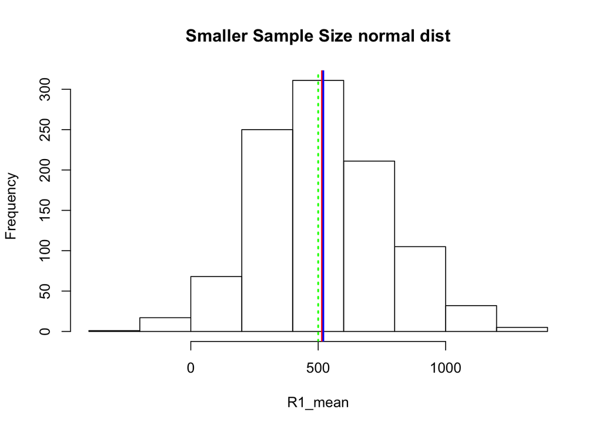

```r
abline(v=R1m, col= "red",lwd=2)#mean of normal sample to histogram mean
abline(v=mean(R1_mean), col= "blue",lwd=2)#mean of sample means compared to normal sample mean
abline(v=500, col= "green",lwd=2, lty=3)#calculated mean from oroginal sample
```

#### Figure 1:

- The histogram for the sampler sample size. The histogram is very close to bieng a normal distribution but it is not quite there yet. This can be seen by comparing the means of the known normal distribution and the mean of the sample.

#### Larger sample size

This next portion uses basically the sample code but increases the sample size. In thoery the output should look a lot more like a normal distribution.

```r
R2 <- 10000#creating another sample size
R2_mean <- numeric(R1)#empty vector
Secondnormal <- rnorm(100000, 1000, 250)#again created a normal selection of random variables with sample size, mean, and std
sample1 <- numeric()#another empty vector
R2m <- mean(Secondnormal)#taking the mean of the random sample
```

Bootstap a data set with a larger sample size:

```r
for(i in 1:10000 ){
sample1 <- sample(Secondnormal, 1:1000, replace = FALSE)
R2_mean[i] <- mean(sample1)}#for loop that bootstraps the data so we can apply the sample mean function multiple times
```

```r
hist(R2_mean, main = "Larger Sample Size Normal Distribution")
summary(R2_mean)#shows summary of the data set
```

```
##    Min. 1st Qu.  Median    Mean 3rd Qu.    Max.
##   29.23  824.30  994.40  994.10 1166.00 1873.00
```

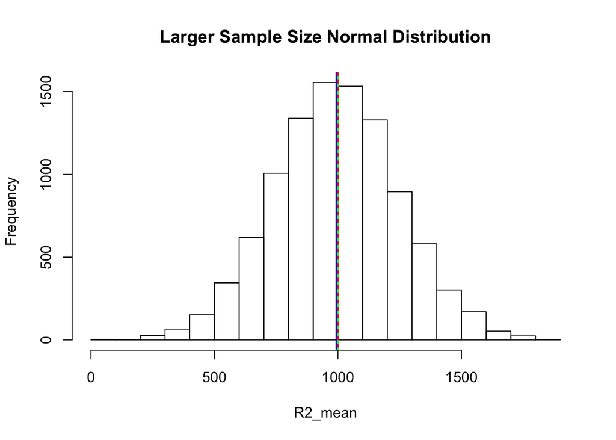

```r
abline(v=R2m, col= "red",lwd=2)#mean of normal sample to histogram mean
abline(v=mean(R2_mean), col= "blue",lwd=2)#shows mean of the sample dataset
abline(v=1000, col= "green",lwd=2, lty=3)#shows estimated mean
```

#### Figure 2:

##### Boxplot for mean data

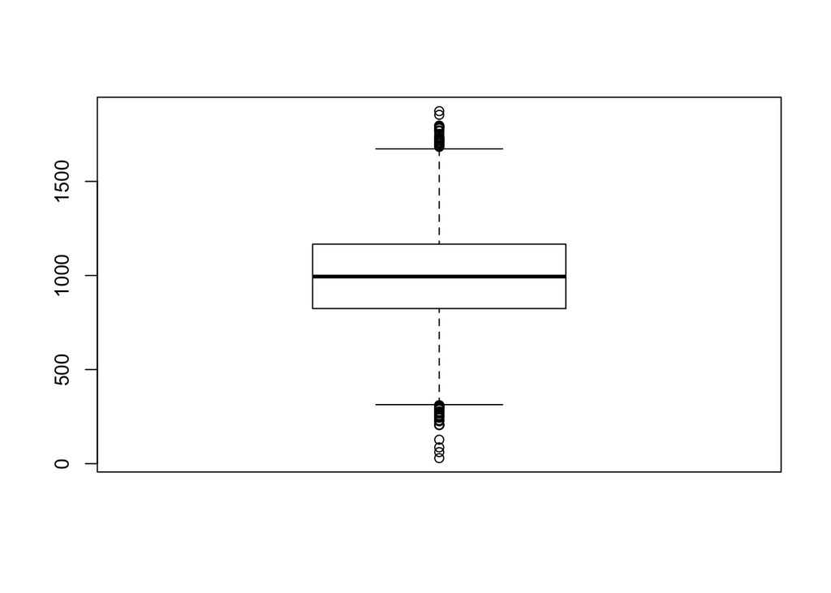

```r
boxplot(R2_mean)#made a boxplot for the sample data
```

#### Figure 3:

- Another way to observe the data is by using a boxplot. A boxplot for a normal distribution is supposed to be evenly distrubuted over the mean.

## Part 2

Using an exponential distribution we again chose a small sample size and observe the sample distribution.

```r
R3<-20
R4<-1000#assigning basic variables
R3_mean <- numeric(R3)#empty vectors
R4_mean <- numeric(R4)
First_Exp <- rexp(100,1)
Second_Exp <-rexp(10000,.1)
```

Here again we run almost the same bootstrapping code but instead of rnorm we are using rexp, which creates a sample from an exponential distribution

```r
for(i in 1:20 ){
sample1 <- sample(First_Exp,1:20, replace = FALSE)
R3_mean[i] <- mean(sample1)}
```

```r
summary(R3_mean)
```

```
##    Min. 1st Qu.  Median    Mean 3rd Qu.    Max.
## 0.04778 0.28170 0.57110 0.94620 1.42800 3.28100
```

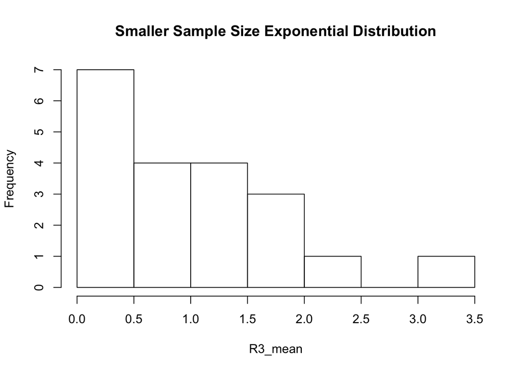

```r
hist(R3_mean, main = "Smaller Sample Size Exponential Distribution")
```

#### Figure 4:

- This is the distribution of the samples selected in a smaller data set. The distribution does not appear to be completely exponential.

```r
for(i in 1:1000 ){
sample1 <- sample(Second_Exp,1:1000, replace = FALSE)
R4_mean[i] <- mean(sample1)}
```

```r
summary(R4_mean)
```

```
##     Min.  1st Qu.   Median     Mean  3rd Qu.     Max.
##  0.01936  2.99300  6.88600  9.43300 13.58000 71.23000
```

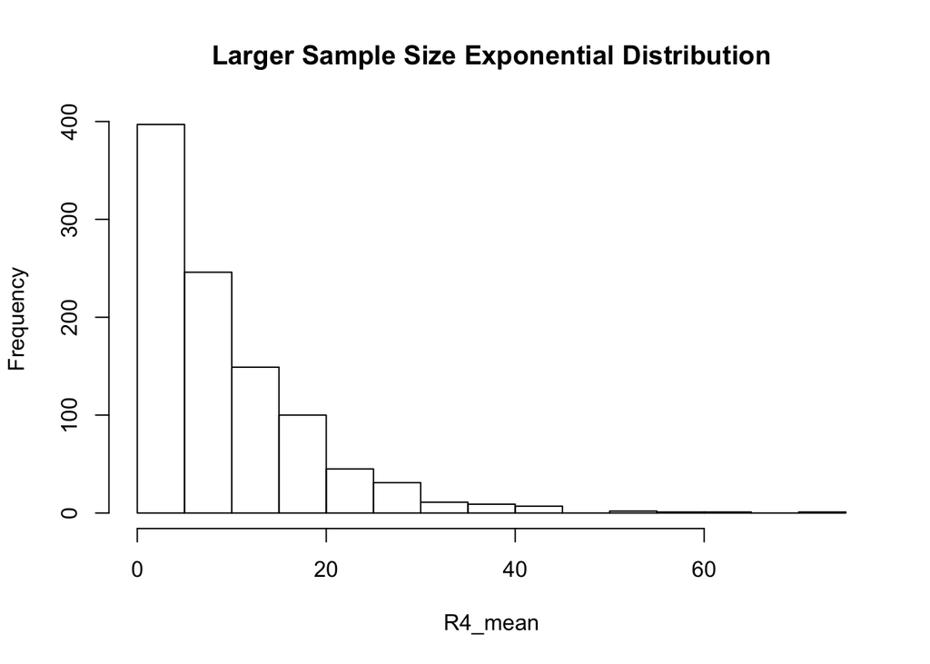

```r
hist(R4_mean, main = "Larger Sample Size Exponential Distribution")
```

#### Figure 5:

- This distribution looks a lot more closer to the what an exponential distribution should look like. Normally they contain a lot of data points closer to zero.

##### Boxplot for mean data

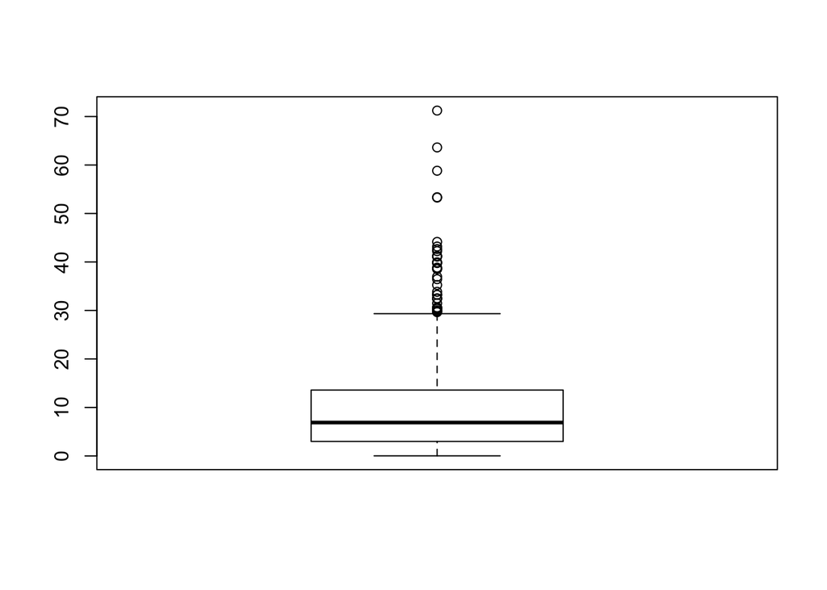

```r
boxplot(R4_mean)#made a boxplot for the sample data
```

#### Figure 6:

- Again we will check the distribution by looking at the same sample using a boxplot. For an exponential distribution you will expect the boxplot to be heavily distributed to one side. Just like the box plot that we see below.